# Session 1 — Causal Questions and DAGs

Association vs causation · potential outcomes · confounder, mediator, collider · adjustment sets · Lab 1

Community Medicine Workshop

## Where we are

- Prediction (A8) asked **who** is at risk. Today: **what would happen if we intervened?**
- By the end you can:
  - state a **causal question** and the **estimand**
  - draw a **DAG** and name **confounders, mediators, colliders**
  - let the DAG choose the **adjustment set**

## Our question: did the programme lower blood pressure?

- **3,000 adults with hypertension** from routine clinic records (synthetic)
- **1,229 (41%) enrolled** in a community health-worker **programme**: **not randomised**
- Outcome: **SBP at 12 months**
- Also recorded: age, sex, education, urban, BMI, diabetes, **baseline SBP**, **adherence** at 6 months, **clinic visits** in the year

```r
htn |> select(age, diabetes, baseline_sbp, programme, adherent, clinic_visits, sbp_12m) |> head(6)
```

```
# A tibble: 6 × 7
    age diabetes baseline_sbp programme adherent clinic_visits sbp_12m
  <dbl>    <dbl>        <dbl>     <dbl>    <dbl>         <dbl>   <dbl>
1    46        0          146         1        0             5     145
2    62        0          138         0        1             5     134
3    63        1          157         0        0             2     171
4    55        0          170         1        0             7     155
5    60        0          173         1        0             2     152
6    57        0          162         0        1             4     155
```

# Topic 1 — The naive comparison

## Enrolled vs not enrolled

```r
htn |> group_by(programme) |> summarise(n = n(), sbp_12m = round(mean(sbp_12m), 1), age = round(mean(age), 1), baseline_sbp = round(mean(baseline_sbp), 1), diabetes = round(mean(diabetes), 2))
```

```
# A tibble: 2 × 6
  programme     n sbp_12m   age baseline_sbp diabetes
      <dbl> <int>   <dbl> <dbl>        <dbl>    <dbl>
1         0  1771    143.  53.2         150.     0.13
2         1  1229    142   57.8         157.     0.25
```

SBP at 12 months is **142 vs 143**: a difference of **−1.4 mmHg**. “The programme hardly works”? But the enrolled were **older**, had a **higher baseline SBP (157 vs 150)** and **more diabetes (25% vs 13%)**. Sicker people enrol: **confounding by indication**. The groups were **never comparable**.

## Potential outcomes

Y¹ = SBP if enrolled Y⁰ = SBP if not enrolled effect for one person = Y¹ − Y⁰

- We only ever see **one** of the two for each person: the **fundamental problem** of causal inference
- **ATE** = average of Y¹ − Y⁰ over **everybody** (what if all enrolled vs none?)
- **ATT** = average over **those who enrolled** (did it help them?)
- A **randomised trial** makes the groups exchangeable. In observational data we need **assumptions**: **no unmeasured confounding** (exchangeability given covariates), **positivity** (everyone could get either option), **consistency** (a well-defined intervention)

# Topic 2 — DAGs

## Three roles a variable can play

| Role | Structure | Adjust? |
| --- | --- | --- |
| **Confounder** | C → exposure and C → outcome | **Yes**: closes a back-door path |
| **Mediator** | exposure → M → outcome | **No** for the total effect (it removes part of the effect) |
| **Collider** | exposure → K ← outcome | **No**: adjusting **opens** a biasing path |

Here: **baseline SBP, age, diabetes, education** are confounders; **adherence** is a **mediator** (the programme works partly by improving adherence); **clinic visits** are a **collider** (the programme brings people in, and so does poor BP).

## The DAG in R

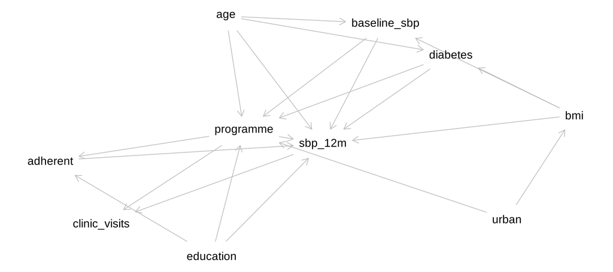

```r
g <- dagitty("dag {
  programme -> sbp_12m ; programme -> adherent -> sbp_12m
  programme -> clinic_visits ; sbp_12m -> clinic_visits
  age -> programme ; age -> sbp_12m ; diabetes -> programme ; diabetes -> sbp_12m
  baseline_sbp -> programme ; baseline_sbp -> sbp_12m
  education -> programme ; education -> sbp_12m ; education -> adherent
  urban -> programme ; urban -> bmi ; bmi -> sbp_12m ; bmi -> baseline_sbp ; bmi -> diabetes
  age -> baseline_sbp ; age -> diabetes
}")
plot(graphLayout(g))
```

## Let the DAG choose

```r
adjustmentSets(g, exposure = "programme", outcome = "sbp_12m", effect = "total")
```

```
{ age, baseline_sbp, bmi, diabetes, education }
{ age, baseline_sbp, diabetes, education, urban }
```

```r
descendants(g, "programme")
```

```
[1] "programme"     "sbp_12m"       "clinic_visits" "adherent"
```

- Two **minimal sufficient sets**: {age, baseline SBP, BMI, diabetes, education} or {age, baseline SBP, diabetes, education, urban}
- **Never** adjust for **descendants** of the exposure (adherent, clinic_visits) when you want the **total** effect
- The DAG encodes **assumptions**, mostly the **arrows you left out**; the data cannot prove it. Draw it **before** the analysis, from subject knowledge

## What a DAG does not do

- It cannot show **unmeasured** confounders you did not think of (here an unrecorded “motivation” exists)
- It says **what** to adjust for, not **how** (functional form, interactions: A6)
- Selecting covariates by **p-values** or stepwise methods is **not** a causal strategy

## 🔧 Switch to R — Lab 1

**File:** `causal-workshop/labs/lab1_dag.R`

- the naive comparison and baseline imbalance
- write the DAG with `dagitty`
- adjustment sets, paths, descendants

**Time:** 35 minutes · answer the Q questions in the comments

## Self-check quiz (1/5)

Enrolled adults had a higher baseline SBP and more diabetes. Why can the naive difference in 12-month SBP not be read as the effect?

- The sample of 3,000 adults is too small to estimate a difference between two means
- The groups differed before the programme, so outcomes would differ anyway
- The outcome was measured at 12 months and not at the time of enrolment in the programme
- The naive difference has a confidence interval, and causal effects do not have one

## Self-check quiz (2/5)

What is the average treatment effect (ATE)?

- The mean difference between the enrolled and the non-enrolled adults as observed
- The mean benefit among the adults who actually enrolled in the programme
- The mean difference if everybody were enrolled versus nobody enrolled
- The largest effect that is seen in any of the subgroups of the cohort

## Self-check quiz (3/5)

Adherence is improved by the programme and lowers SBP. If you want the total effect of the programme, should you adjust for adherence?

- Yes: it is a confounder, since it is related to both variables
- Yes: adjusting for more variables makes the estimate less biased
- No: adherence was measured after baseline, so it carries no information
- No: it is a mediator, and adjusting removes part of the effect

## Self-check quiz (4/5)

Clinic visits are increased by the programme and by a high SBP. What happens if you adjust for clinic visits?

- A biasing path is opened, because clinic visits are a collider
- The confounding by baseline SBP is removed more completely than before
- Nothing changes, because clinic visits are not a cause of the 12-month SBP
- The estimate becomes the direct effect of the programme on blood pressure

## Self-check quiz (5/5)

What is the best source for the arrows in a DAG?

- The p-values of the associations between the variables found in the data
- Subject knowledge about how the variables arise, set down in advance
- A stepwise selection procedure applied to all of the measured variables
- The correlation matrix of the variables, with a cut-off of 0.3 for an arrow

## Score and take-home

**Your score:**

- **Causal question** → estimand (**ATE**, **ATT**) → assumptions
- **Confounder**: adjust. **Mediator, collider**: do not (for the total effect)
- **DAG first**, from subject knowledge; `adjustmentSets()`
- The naive comparison is **confounded by indication**
- A DAG cannot reveal **unmeasured** confounders

**Next:** Session 2: adjustment, bad controls and standardisation